# Pharma Industry Analysis

SAKSHI

2023-11-10

## Question

An equities analyst is studying the pharmaceutical industry and would like your help in exploring and understanding the financial data collected by her firm. Her main objective is to understand the structure of the pharmaceutical industry using some basic financial measures. Financial data gathered on 21 firms in the pharmaceutical industry are available in the file Pharmaceuticals.csv Download Pharmaceuticals.csv. For each firm, the following variables are recorded:

-Market capitalization (in billions of dollars) -Beta -Price/earnings ratio -Return on equity -Return on assets -Asset turnover -Leverage -Estimated revenue growth -Net profit margin -Median recommendation (across major brokerages) -Location of firm’s headquarters -Stock exchange on which the firm is listed -Use cluster analysis to explore and analyze the given dataset as follows:

1.Use only the numerical variables (1 to 9) to cluster the 21 firms. Justify the various choices made in conducting the cluster analysis, such as weights for different variables, the specific clustering algorithm(s) used, the number of clusters formed, and so on.

2.Interpret the clusters with respect to the numerical variables used in forming the clusters. Is there a pattern in the clusters with respect to the numerical variables (10 to 12)? (those not used in forming the clusters).

3.Provide an appropriate name for each cluster using any or all of the variables in the dataset.

## Summary

1.k-means is the most appropriate clustering algorithm with k=5.

2.we got 5 clusters-

one with highest Market_Cap, highest ROE, highest ROA, highest Asset_Turnover has equal Hold and Moderate Buy Recommendation.

3. We got 5 types of companies- Startups , MNCs, Unicorns, Gamble and Leveraged.

### Loading all the required packages

```r
library(tidyverse)
library(cluster)
library(factoextra)
library(ISLR)
library(caret)
library(tidyr)
library(readr)
library(knitr)
library(dplyr)
library(stats)
library(dbscan)
```

### Loading the dataset into the R

```r
pharma.df.2 <- read.csv("/Users/sakshibansal/Downloads/Pharmaceuticals.csv")
```

### Understanding the data structure

```r
dim(pharma.df.2)
```

```
[1] 21 14
```

```r
head(pharma.df.2, n=10)
```

```
   Symbol                         Name Market_Cap Beta PE_Ratio  ROE  ROA
1     ABT          Abbott Laboratories      68.44 0.32     24.7 26.4 11.8
2     AGN               Allergan, Inc.       7.58 0.41     82.5 12.9  5.5
3     AHM                 Amersham plc       6.30 0.46     20.7 14.9  7.8
4     AZN              AstraZeneca PLC      67.63 0.52     21.5 27.4 15.4
5     AVE                      Aventis      47.16 0.32     20.1 21.8  7.5
6     BAY                     Bayer AG      16.90 1.11     27.9  3.9  1.4
7     BMY Bristol-Myers Squibb Company      51.33 0.50     13.9 34.8 15.1
8    CHTT                 Chattem, Inc       0.41 0.85     26.0 24.1  4.3
9     ELN        Elan Corporation, plc       0.78 1.08      3.6 15.1  5.1
10    LLY        Eli Lilly and Company      73.84 0.18     27.9 31.0 13.5
   Asset_Turnover Leverage Rev_Growth Net_Profit_Margin Median_Recommendation
1             0.7     0.42       7.54              16.1          Moderate Buy
2             0.9     0.60       9.16               5.5          Moderate Buy
3             0.9     0.27       7.05              11.2            Strong Buy
```

[output cut: 18 more lines]

```r
str(pharma.df.2)
```

```
'data.frame':   21 obs. of  14 variables:
 $ Symbol               : chr  "ABT" "AGN" "AHM" "AZN" ...
 $ Name                 : chr  "Abbott Laboratories" "Allergan, Inc." "Amersham plc" "AstraZeneca PLC" ...
 $ Market_Cap           : num  68.44 7.58 6.3 67.63 47.16 ...
 $ Beta                 : num  0.32 0.41 0.46 0.52 0.32 1.11 0.5 0.85 1.08 0.18 ...
 $ PE_Ratio             : num  24.7 82.5 20.7 21.5 20.1 27.9 13.9 26 3.6 27.9 ...
 $ ROE                  : num  26.4 12.9 14.9 27.4 21.8 3.9 34.8 24.1 15.1 31 ...
 $ ROA                  : num  11.8 5.5 7.8 15.4 7.5 1.4 15.1 4.3 5.1 13.5 ...
 $ Asset_Turnover       : num  0.7 0.9 0.9 0.9 0.6 0.6 0.9 0.6 0.3 0.6 ...
 $ Leverage             : num  0.42 0.6 0.27 0 0.34 0 0.57 3.51 1.07 0.53 ...
 $ Rev_Growth           : num  7.54 9.16 7.05 15 26.81 ...
 $ Net_Profit_Margin    : num  16.1 5.5 11.2 18 12.9 2.6 20.6 7.5 13.3 23.4 ...
 $ Median_Recommendation: chr  "Moderate Buy" "Moderate Buy" "Strong Buy" "Moderate Sell" ...
 $ Location             : chr  "US" "CANADA" "UK" "UK" ...
 $ Exchange             : chr  "NYSE" "NYSE" "NYSE" "NYSE" ...
```

```r
summary(pharma.df.2)
```

```
    Symbol              Name             Market_Cap          Beta
 Length:21          Length:21          Min.   :  0.41   Min.   :0.1800
 Class :character   Class :character   1st Qu.:  6.30   1st Qu.:0.3500
 Mode  :character   Mode  :character   Median : 48.19   Median :0.4600
                                       Mean   : 57.65   Mean   :0.5257
                                       3rd Qu.: 73.84   3rd Qu.:0.6500
                                       Max.   :199.47   Max.   :1.1100
    PE_Ratio          ROE            ROA        Asset_Turnover    Leverage
 Min.   : 3.60   Min.   : 3.9   Min.   : 1.40   Min.   :0.3    Min.   :0.0000
 1st Qu.:18.90   1st Qu.:14.9   1st Qu.: 5.70   1st Qu.:0.6    1st Qu.:0.1600
 Median :21.50   Median :22.6   Median :11.20   Median :0.6    Median :0.3400
 Mean   :25.46   Mean   :25.8   Mean   :10.51   Mean   :0.7    Mean   :0.5857
 3rd Qu.:27.90   3rd Qu.:31.0   3rd Qu.:15.00   3rd Qu.:0.9    3rd Qu.:0.6000
 Max.   :82.50   Max.   :62.9   Max.   :20.30   Max.   :1.1    Max.   :3.5100
   Rev_Growth    Net_Profit_Margin Median_Recommendation   Location
 Min.   :-3.17   Min.   : 2.6      Length:21             Length:21
 1st Qu.: 6.38   1st Qu.:11.2      Class :character      Class :character
 Median : 9.37   Median :16.1      Mode  :character      Mode  :character
 Mean   :13.37   Mean   :15.7
 3rd Qu.:21.87   3rd Qu.:21.1
 Max.   :34.21   Max.   :25.5
   Exchange
 Length:21
 Class :character
 Mode  :character
```

### Cleaning the data to remove every n/a values

```r
pharma.df.2 <- na.omit(pharma.df.2)
```

**1a.Use only the numerical variables (1 to 9) to cluster the 21 firms**

### Dropping all the non-numeric varaibles

```r
pharma.df = pharma.df.2[ , c(3:11)]
pharma.df
```

```
   Market_Cap Beta PE_Ratio  ROE  ROA Asset_Turnover Leverage Rev_Growth
1       68.44 0.32     24.7 26.4 11.8            0.7     0.42       7.54
2        7.58 0.41     82.5 12.9  5.5            0.9     0.60       9.16
3        6.30 0.46     20.7 14.9  7.8            0.9     0.27       7.05
4       67.63 0.52     21.5 27.4 15.4            0.9     0.00      15.00
5       47.16 0.32     20.1 21.8  7.5            0.6     0.34      26.81
6       16.90 1.11     27.9  3.9  1.4            0.6     0.00      -3.17
7       51.33 0.50     13.9 34.8 15.1            0.9     0.57       2.70
8        0.41 0.85     26.0 24.1  4.3            0.6     3.51       6.38
9        0.78 1.08      3.6 15.1  5.1            0.3     1.07      34.21
10      73.84 0.18     27.9 31.0 13.5            0.6     0.53       6.21
11     122.11 0.35     18.0 62.9 20.3            1.0     0.34      21.87
12       2.60 0.65     19.9 21.4  6.8            0.6     1.45      13.99
13     173.93 0.46     28.4 28.6 16.3            0.9     0.10       9.37
14       1.20 0.75     28.6 11.2  5.4            0.3     0.93      30.37
```

[output cut: 29 more lines]

### Normalizing the dataset

```r
df.norm = preProcess(pharma.df , method = c("center", "scale"))
pharma.norm = predict(df.norm , pharma.df)
```

### Finding the value of k using elbow and silhouette method

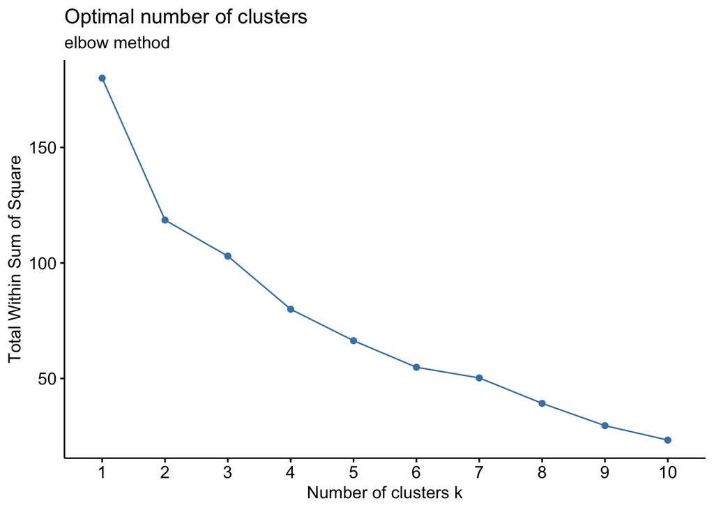

```r
fviz_nbclust(pharma.norm , kmeans , method = "wss") + labs(subtitle = "elbow method")
```

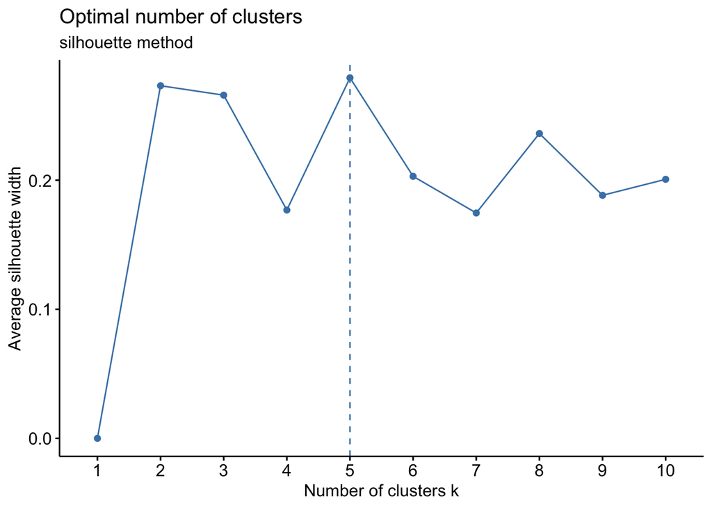

```r
fviz_nbclust(pharma.norm , kmeans , method = "silhouette") + labs(subtitle = "silhouette method")
```

### Now making clusters and visualizing it using k-means

```r
set.seed(250)
kcluster <- kmeans(pharma.norm , centers = 5 , nstart = 25)
kcluster$centers
```

```
   Market_Cap       Beta    PE_Ratio        ROE        ROA Asset_Turnover
1 -0.76022489  0.2796041 -0.47742380 -0.7438022 -0.8107428     -1.2684804
2  1.69558112 -0.1780563 -0.19845823  1.2349879  1.3503431      1.1531640
3 -0.43925134 -0.4701800  2.70002464 -0.8349525 -0.9234951      0.2306328
4 -0.03142211 -0.4360989 -0.31724852  0.1950459  0.4083915      0.1729746
5 -0.87051511  1.3409869 -0.05284434 -0.6184015 -1.1928478     -0.4612656
     Leverage Rev_Growth Net_Profit_Margin
1  0.06308085  1.5180158      -0.006893899
2 -0.46807818  0.4671788       0.591242521
3 -0.14170336 -0.1168459      -1.416514761
4 -0.27449312 -0.7041516       0.556954446
5  1.36644699 -0.6912914      -1.320000179
```

```r
kcluster$size
```

```
[1] 4 4 2 8 3
```

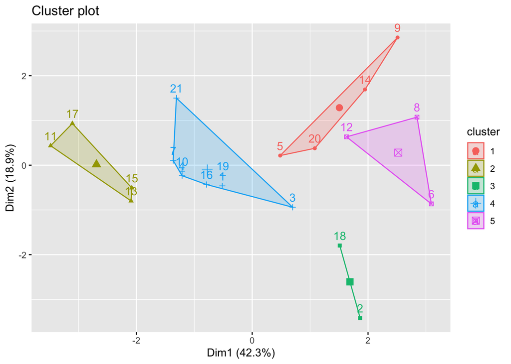

```r
fviz_cluster(kcluster , data = pharma.norm)
```

We can clearly see the 5 clusters being made.

### Making cluster using the dbscan method

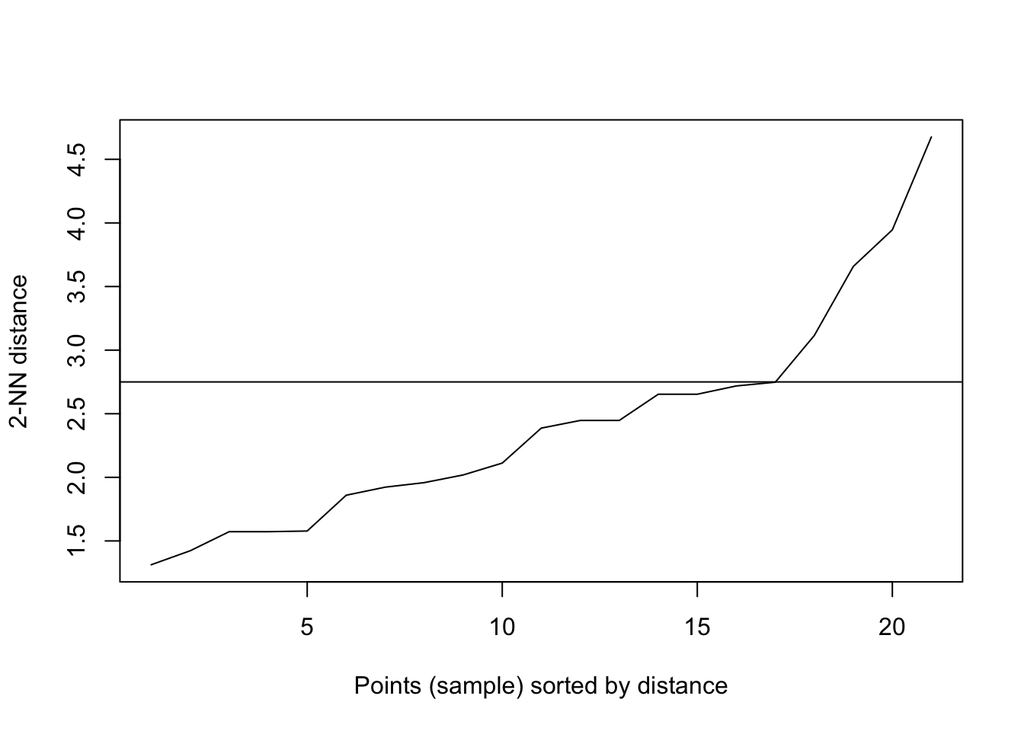

```r
# Finding the optimal value of eps
dbscan::kNNdistplot(pharma.norm , k=2)
abline(h = 2.75)
```

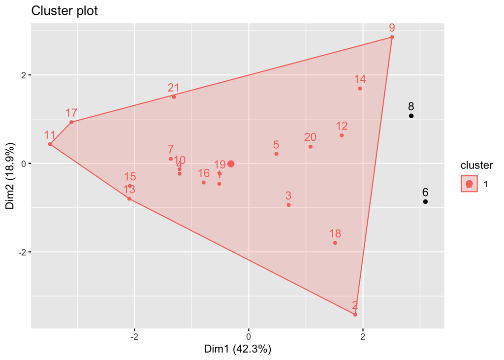

```r
pharma.db <- dbscan::dbscan(pharma.norm , eps = 2.75 , minPts = 2)

fviz_cluster(pharma.db , pharma.norm)
```

We can clearly see the 1 cluster being made with two outliers.

### Making cluster using the hierarchical method

```r
# Using agnes and finding the best linkage method

pharma.single <- agnes(pharma.norm , method = "single")
pharma.complete <- agnes(pharma.norm , method = "complete")
pharma.average <- agnes(pharma.norm , method = "average")

# Comparing their agglomerative function

print(pharma.single$ac)
```

```
[1] 0.4600348
```

```r
print(pharma.complete$ac)
```

```
[1] 0.6990833
```

```r
print(pharma.average$ac)
```

```
[1] 0.5600652
```

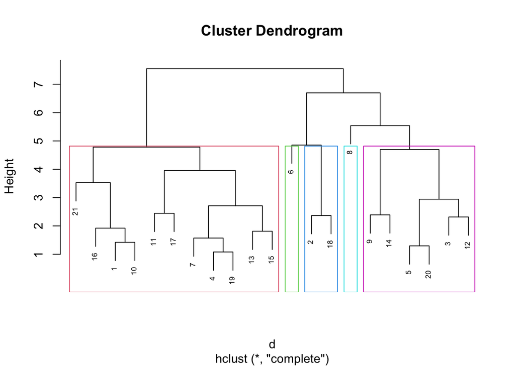

```r
# We are going with the complete one since it has highest agglomerative function

# Using hclust to make the clusters
d <- dist(pharma.norm , method = "euclidean")
pharma.complete.2 <- hclust(d, method = "complete")
plot(pharma.complete.2 , cex = 0.6)
rect.hclust(pharma.complete.2 , k=5 , border=2:6)
```

We can clearly see the 5 clusters being made.

**1b.Justify the various choices made in conducting the cluster analysis, such as weights for different variables, the specific clustering algorithm(s) used, the number of clusters formed, and so on.**

**Interpretation**

As we don’t want the clustering algorithm to depend to an arbitrary variable unit, we started by normalizing the data and setting equal weights to all the variables so we can get a more clear picture of the clusters.

Lastly, between k-means , dbscan and hierarchical method, I believe k-means is a more appropriate fit for clustering this dataset because both the other methods gave us outliers which should have been included in the dataset since they are very close to the other points as shown in k-means clustering. Furthermore, this is a financial dataset and there is no hierarchy in it which means we can’t do clustering on the basis of the same.

**2.Interpret the clusters with respect to the numerical variables used in forming the clusters.**

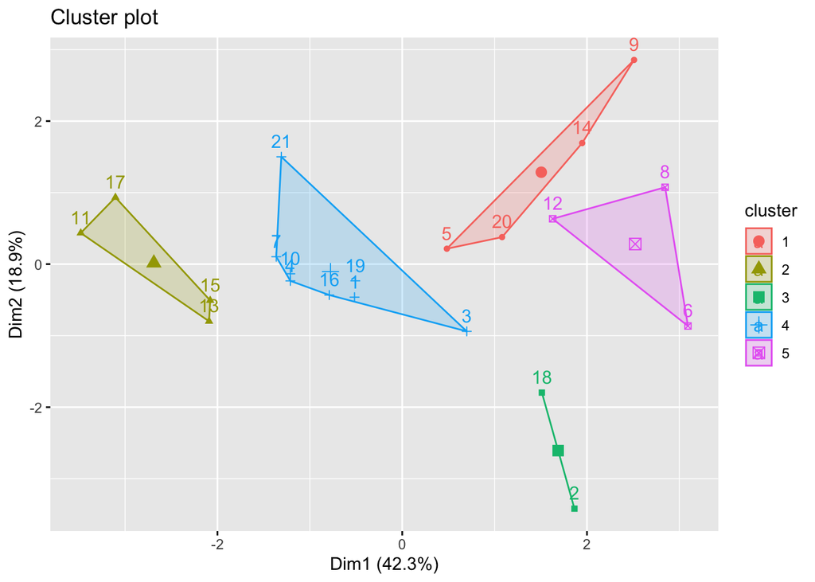

```r
fviz_cluster(kcluster , data = pharma.norm)
```

```r
cluster1 <- kable(pharma.norm[c(5,9,14,20),], align = "c")
cluster1
```

|  | Market_Cap | Beta | PE_Ratio | ROE | ROA | Asset_Turnover | Leverage | Rev_Growth | Net_Profit_Margin |
| --- | --- | --- | --- | --- | --- | --- | --- | --- | --- |
| 5 | -0.1790256 | -0.8012536 | -0.3287443 | -0.2648488 | -0.5664461 | -0.4612656 | -0.3144900 | 1.216387 | -0.4259704 |
| 9 | -0.9704532 | 2.1589332 | -1.3403777 | -0.7089994 | -1.0174553 | -1.8450624 | 0.6198379 | 1.886171 | -0.3650138 |
| 14 | -0.9632863 | 0.8735889 | 0.1924001 | -0.9675348 | -0.9610792 | -1.8450624 | 0.4406517 | 1.538607 | 0.8541178 |
| 20 | -0.9281345 | -1.1128522 | -0.4329732 | -1.0338259 | -0.6979905 | -0.9225312 | -0.4936762 | 1.430899 | -0.0907092 |

```r
cluster2 <- kable(pharma.norm[c(11,15,17,13),], align = "c")
cluster2
```

|  | Market_Cap | Beta | PE_Ratio | ROE | ROA | Asset_Turnover | Leverage | Rev_Growth | Net_Profit_Margin |
| --- | --- | --- | --- | --- | --- | --- | --- | --- | --- |
| 11 | 1.099920 | -0.6844041 | -0.4574977 | 2.4597165 | 1.8389364 | 1.3837968 | -0.3144900 | 0.7692605 | 0.8236395 |
| 15 | 1.278239 | -0.2559560 | -0.4023177 | 0.9814243 | 0.8429577 | 1.8450624 | -0.3912841 | 0.3601491 | -0.2431006 |
| 17 | 2.419990 | 0.4840907 | -0.1141555 | 1.3128800 | 1.6322239 | 0.4612656 | -0.5448723 | 1.1014372 | 1.4484444 |
| 13 | 1.984176 | -0.2559560 | 0.1801379 | 0.1859308 | 1.0872544 | 0.9225312 | -0.6216663 | -0.3621317 | 0.3359869 |

All companies in this cluster have high values besides Beta, PE ratio and Leverage.

```r
cluster3 <- kable(pharma.norm[c(2,18),], align = "c")
cluster3
```

|  | Market_Cap | Beta | PE_Ratio | ROE | ROA | Asset_Turnover | Leverage | Rev_Growth | Net_Profit_Margin |
| --- | --- | --- | --- | --- | --- | --- | --- | --- | --- |
| 2 | -0.8544181 | -0.4507051 | 3.497069 | -0.8548399 | -0.9422871 | 0.9225312 | 0.0182843 | -0.3811391 | -1.553667 |
| 18 | -0.0240846 | -0.4896550 | 1.902980 | -0.8150652 | -0.9047030 | -0.4612656 | -0.3016910 | 0.1474473 | -1.279362 |

This cluster has a high PE ratio but very low values for other variables.

```r
cluster4 <- kable(pharma.norm[c(1,3,4,7,10,16,19,21),], align = "c")
cluster4
```

|  | Market_Cap | Beta | PE_Ratio | ROE | ROA | Asset_Turnover | Leverage | Rev_Growth | Net_Profit_Margin |
| --- | --- | --- | --- | --- | --- | --- | --- | --- | --- |
| 1 | 0.1840960 | -0.8012536 | -0.0467132 | 0.0400903 | 0.2416121 | 0.0000000 | -0.2120979 | -0.5277675 | 0.0616823 |
| 3 | -0.8762600 | -0.2559560 | -0.2919577 | -0.7222576 | -0.5100700 | 0.9225312 | -0.4040831 | -0.5721181 | -0.6850358 |
| 4 | 0.1702742 | -0.0222570 | -0.2429088 | 0.1063815 | 0.9181259 | 0.9225312 | -0.7496565 | 0.1474473 | 0.3512260 |
| 7 | -0.1078688 | -0.1001567 | -0.7088733 | 0.5969358 | 0.8617498 | 0.9225312 | -0.0201127 | -0.9658426 | 0.7474438 |
| 10 | 0.2762415 | -1.3465511 | 0.1494823 | 0.3450295 | 0.5610770 | -0.4612656 | -0.0713088 | -0.6481476 | 1.1741398 |
| 16 | 0.6654710 | -1.3076013 | -0.2367777 | -0.5233842 | 0.1288598 | -0.9225312 | -0.6728624 | -1.4536989 | 1.0217484 |
| 19 | -0.4018812 | -0.0612069 | -0.4023177 | -0.2118159 | 0.5234929 | 0.4612656 | -0.7496565 | -0.4354459 | 0.2902694 |
| 21 | -0.1614497 | 0.4061910 | -0.7579221 | 1.9293875 | 0.5422849 | -0.4612656 | 0.6838330 | -1.1776392 | 1.4941618 |

```r
cluster5 <- kable(pharma.norm[c(6,8,12),], align = "c")
cluster5
```

|  | Market_Cap | Beta | PE_Ratio | ROE | ROA | Asset_Turnover | Leverage | Rev_Growth | Net_Profit_Margin |
| --- | --- | --- | --- | --- | --- | --- | --- | --- | --- |
| 6 | -0.6953818 | 2.2757827 | 0.1494823 | -1.4514600 | -1.7127612 | -0.4612656 | -0.7496565 | -1.4971443 | -1.9956023 |
| 8 | -0.9767669 | 1.2630872 | 0.0329912 | -0.1123792 | -1.1677918 | -0.4612656 | 3.7427970 | -0.6327607 | -1.2488842 |
| 12 | -0.9393967 | 0.4840907 | -0.3410066 | -0.2913653 | -0.6979905 | -0.4612656 | 1.1062004 | 0.0560309 | -0.7155141 |

This cluster has high beta value , average per ration and all other variables have mixed values.

**Is there a pattern in the clusters with respect to the numerical variables (10 to 12)? (those not used in forming the clusters).**

### Identifying the patter of remaining variables

```r
cluster_Pattern <- pharma.df.2 %>%
  select(c(1,12,13,14)) %>%
  mutate(Cluster = kcluster$clust)
print(cluster_Pattern)
```

```
   Symbol Median_Recommendation    Location Exchange Cluster
1     ABT          Moderate Buy          US     NYSE       4
2     AGN          Moderate Buy      CANADA     NYSE       3
3     AHM            Strong Buy          UK     NYSE       4
4     AZN         Moderate Sell          UK     NYSE       4
5     AVE          Moderate Buy      FRANCE     NYSE       1
6     BAY                  Hold     GERMANY     NYSE       5
7     BMY         Moderate Sell          US     NYSE       4
8    CHTT          Moderate Buy          US   NASDAQ       5
9     ELN         Moderate Sell     IRELAND     NYSE       1
10    LLY                  Hold          US     NYSE       4
11    GSK                  Hold          UK     NYSE       2
12    IVX                  Hold          US     AMEX       5
13    JNJ          Moderate Buy          US     NYSE       2
14    MRX          Moderate Buy          US     NYSE       1
15    MRK                  Hold          US     NYSE       2
16    NVS                  Hold SWITZERLAND     NYSE       4
17    PFE          Moderate Buy          US     NYSE       2
18    PHA                  Hold          US     NYSE       3
19    SGP                  Hold          US     NYSE       4
20    WPI         Moderate Sell          US     NYSE       1
21    WYE                  Hold          US     NYSE       4
```

### Now visualizing the data points to find the pattern

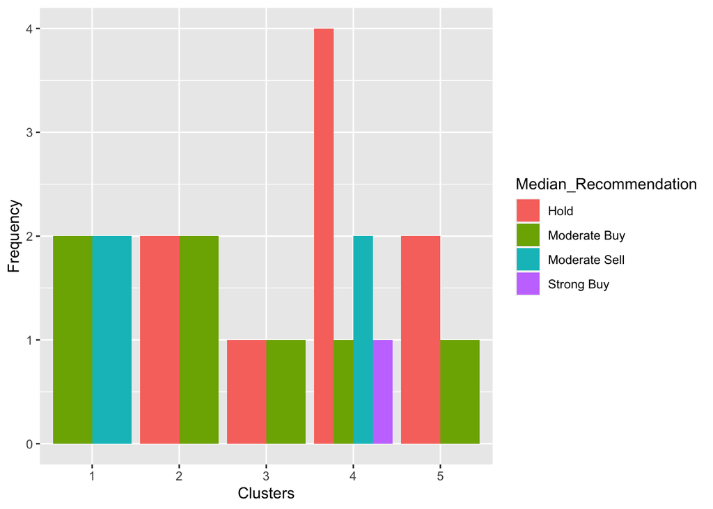

```r
ggplot(cluster_Pattern, mapping = aes(factor(Cluster), fill=Median_Recommendation)) + geom_bar(position = 'dodge') + labs(x='Clusters', y='Frequency')
```

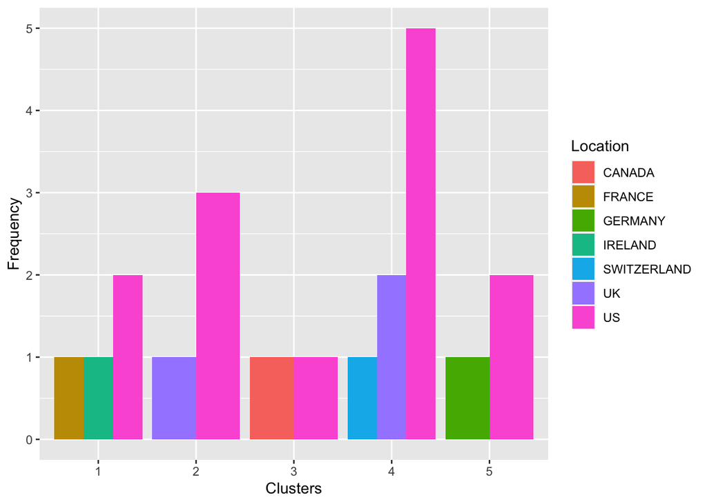

```r
ggplot(cluster_Pattern, mapping = aes(factor(Cluster), fill=Location)) + geom_bar(position = 'dodge') + labs(x='Clusters', y='Frequency')
```

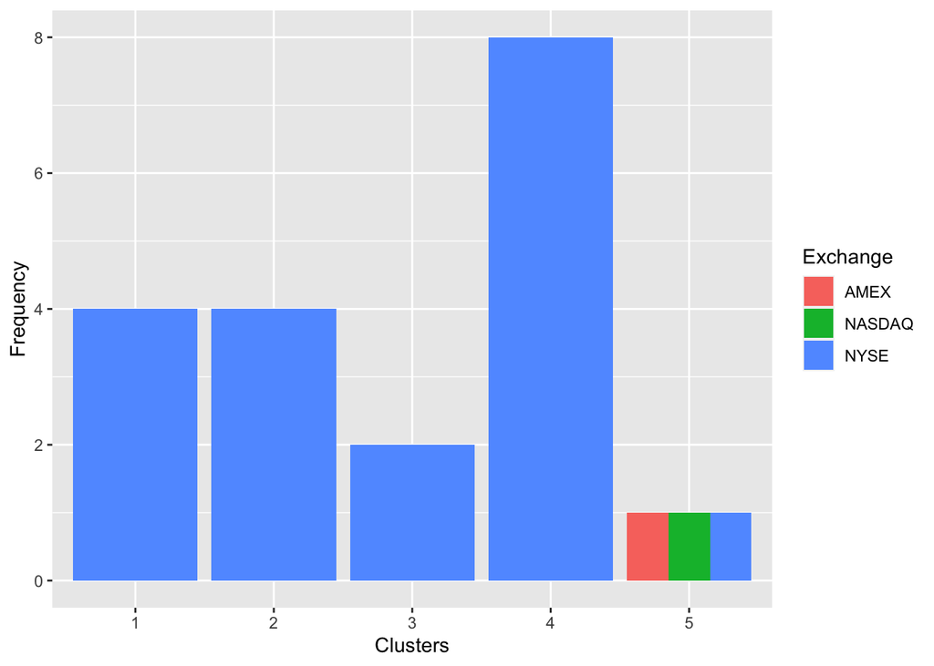

```r
ggplot(cluster_Pattern, mapping = aes(factor(Cluster), fill=Exchange)) + geom_bar(position = 'dodge') + labs(x='Clusters', y='Frequency')
```

**Interpretation**

From all the above graphs we can say-

cluster2 - All the companies are listed in NYSE and trades from two locations which are UK AND US. Also, they are indulged in partially hold and moderate buy.

cluster3 - All the companies are listed in NYSE and trades from two locations which are Canada AND US. Also, they are indulged in very low hold and moderate buy.

cluster4 - All the companies are listed in NYSE and trades from various locations like Switzerland, UK and US being the dominant one. Also, they are indulged in highest hold with very low moderate/strong buy.

cluster5 - All the companies are listed in all 3 exchanges and trades from Germany and US. Also, they are indulged in average hold and low moderate buy.

In terms of variables, a pattern can be seen among the clusters (10 to 12).

Clusters 2,3,4,5 has Hold Recommendation

**3.Provide an appropriate name for each cluster using any or all of the variables in the dataset.**

**Cluster 2 - “MNC”**: Companies with high market capitalization are typically large and well-established companies that have a significant market presence and a strong financial position. We can say that this cluster consists of settled and profitable companies.

**Cluster 3 - “Gamble”**: since it has high price-to-earnings (PE) ratio and a low net profit margin means that such companies can be risky, as they may not be able to meet the market’s expectations and may experience a decline in stock price in the future.We can say that this cluster consists of overpriced and risky companies

**Cluster 4 - “Unicorns”**: company with normal levels across financial metrics can be considered that the company is operating efficiently and effectively.We can say that this cluster consists of stable and efficient companies

**Cluster 5 - “Leveraged”**: Companies with high leverage and low net profit margin & ROA may indicate that the company is taking on a significant amount of debt to finance its operations, while not generating a sufficient level of profitability or returns on assets.We can say that this cluster consists of debt-ridden and very risky companies.